# Series de tiempo de indices de vegetación

veronica_barraza

2022-11-06

## Series temporales de índices de vegetación

Algunas de las aplicaciones más comunes de los índices de vegetación provenientes de imágenes satelitales incluyen monitoreo de áreas agrícolas, caracterización y detección de cambios en las coberturas terrestres y ordenamiento territorial.

Los sensores ópticos (MODIS sobre Aqua/Terra, OLI de Landsat, MSI en Sentinel 2 ) son en general los más utilizados y accesibles, dados los extensos antecedentes de la teledetección en esta región del espectro electromagnético y su facilidad para la interpretación visual directa. Existe un compromiso entre la resolución espacial y la resolución temporal.

Los sensores MODIS (Moderate-resolution Imaging Spectroadiometer ) a bordo de los satélites Terra y Aqua (lanzados en 1999 y 2002 respectivamente, y aún en funcionamiento) son los que logran el menor tiempo de revisita, pero su resolución espacial es considerada moderada. MODIS es un radiómetro con 36 bandas en la región del espectro electromagnético que va del óptico hasta el infrarrojo térmico. Dos bandas, una en el rojo y otra en el infrarrojo cercano, son sensadas a 250 metros de resolución, mientras que el resto de las bandas poseen 500 ó 1000 metros de resolución. Las características del instrumento permiten a MODIS completar una imagen de la Tierra cada uno o dos días.Sin embargo, el interés en MODIS va mucho más allá de las imágenes de reflectancias. Una gran variedad de productos son generados por especialistas a partir de las imágenes MODIS.

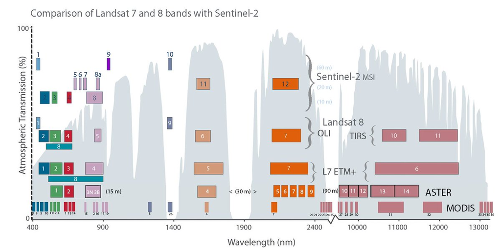

MODIS

Existen diferentes productos obtenidos a partir de las imágenes MODIS. En este estudio utilizamos uno de los productos enfocados al estudio de las cubiertas terrestres (MODLAND) obtenidos con el satélite Terra.

- Los índices de vegetación (producto MOD13) son transformaciones matemáticas de las bandas espectrales originalmente captadas por el sensor remoto. Ejemplos de estos son: el índice de vegetación de diferencia normalizada (NDVI) y el índice de vegetación mejorado (EVI). El índice de diferencia normalizada se produce mediante el cálculo del cociente normalizado de la banda del infrarrojo cercano y la banda del rojo.

## Dataset

En este análisis utilizaremos el producto MOD13Q1 de MODIS, tiles H12V11 y H12V12, para extraer las series de tiempo que correspondan a bosque nativo y deforestación. Cada tile representa una región de aproximadamente 1200 x 1200 km2 ; contiene 4800x4800 píxeles.

El monitoreo de los bosques nativos es sumamente importante para la conservación de la biodiversidad, la lucha contra el cambio climático, y la cuantificación de sus servicios ecosistémicos, por nombrar solamente algunas de las razones. Sin embargo, los bosques nativos del Parque Chaqueño argentino experimentan un proceso de deforestación y degradación cuyas tasas están entre las más altas del mundo. Desde la sanción de la Ley de Bosques en 2007 (Ley Nacional 26.331), diversos esfuerzos han apuntado a monitorear el estado de los bosques nativos.

En este contexto, el análisis de series temporales de datos satelitales resulta de mucho interes. Para este video utilizaremos directamente las series temporales que ya han sido pre-procesadas. Las mismas formaron parte de un trabajo realizado en el marco de un proyecto de investgación que tenía el objetivo mencionado anteriormente y formaron parte de la tesis doctoral del Dr. Esteban Roitbert.

## Área de estudio: Bosque Chaqueño

- Es la segunda área boscosa más extensa en Sudamérica luego del Amazonas
- Cubre 65 millones de ha.
- Incluye el área continua de bosque más extensa de Argentina, con sitios valiosos para la conservación.
- Sectores con procesos activos de deforestación en diferente grado de desarrollo.
- Los frentes de deforestación más antiguos están localizados en el noreste de Tucumán y el oeste de la provincia del Chaco

## Gráfico de una serie temporal de EVI

### Serie de bosque

```r
data <- read.csv("data/sitio1_bosque_train.csv")
#head(data)
```

### Visualización espacial de los puntos

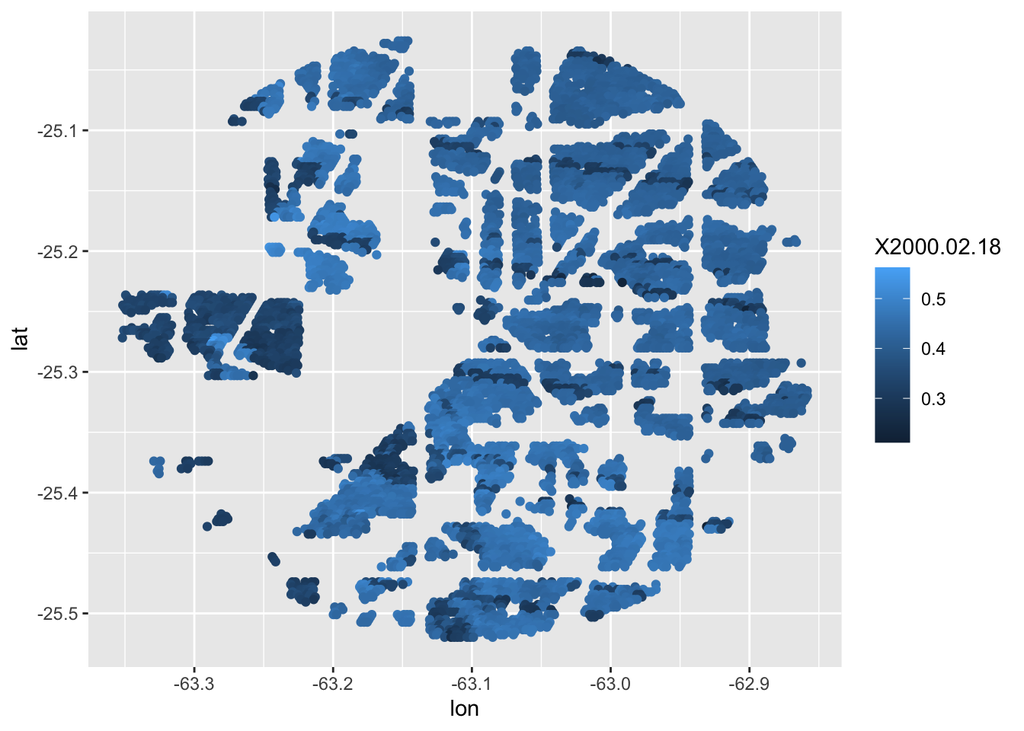

```r
library(ggplot2)
espacial<- data[,c(2,3,8)]
p <-ggplot() + geom_point(data = espacial, aes(x = lon, y = lat, color = X2000.02.18))

p
```

### Visualización temporal de los puntos

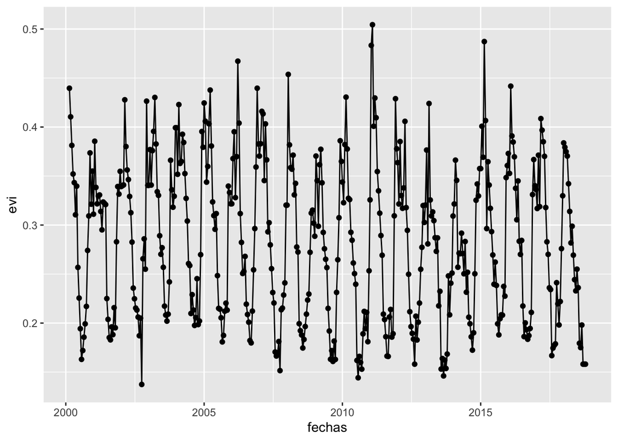

```r
library(ggplot2)

subset <- t(data[1,8:437])
subset <-subset %>% as.data.frame(row.names = 1:nrow(.))

subset<- merge(fechas,subset, by= 'row.names', all = TRUE)
names(subset)<- c('ind','fechas','evi')
# basic scatterplot
ggplot(subset,aes(x=fechas, y=evi)) +
    geom_point() + geom_line(color="black")
```

```r
na.cnt <- length(subset$evi[is.na(subset$evi)])
na.cnt
```

```
## [1] 0
```

En R “ts” es la función genérica para que los datos tengan forma de serie temporal. Su sintaxis es la siguiente:

> ts(data = NA, start = 1, end = numeric(), frequency = 1, deltat = 1, ts.eps = getOption(“ts.eps”), class = , names = )

De esta sintaxis hay que tener presentes los siguiente argumentos:

- data: Vector, “data frame” o matriz de datos.
- start: Referencia de la primera observacion, es un vector con dos valores numéricos, el primero relativo al año y el segundo relativo al trimestre y mes de inicio (1 para el primer trimestre y 1 para enero en series de datos mensuales).
- end: Referencia de la ultima observación.
- frequency: Número de observaciones por año (4 en series trimestrales, 12 en series mensuales).

Vamos a convertir la serie de tiempo de bosque de EVI en un objeto de ts:

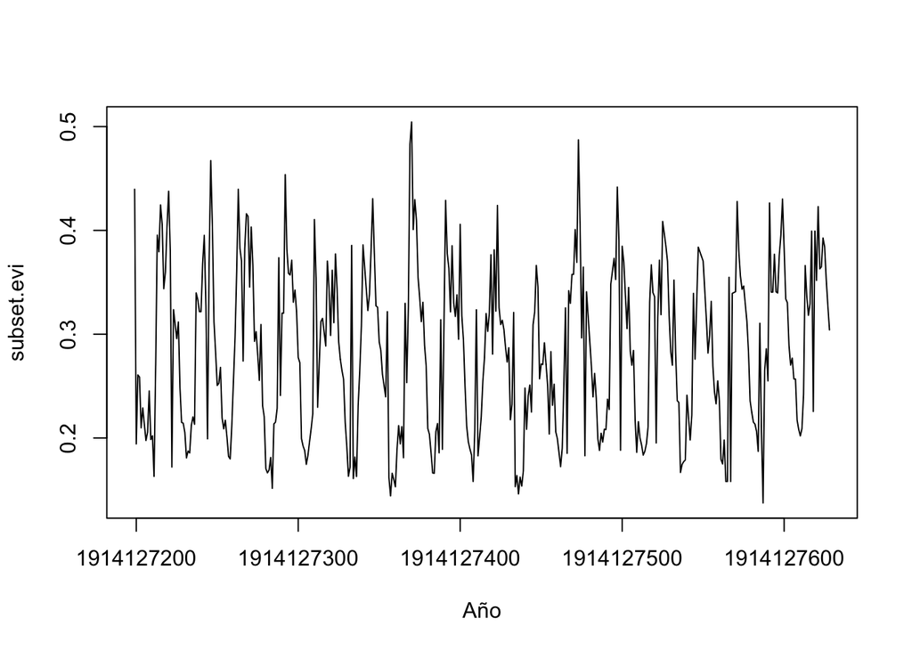

```r
subset.evi<- ts(subset$evi,subset$fechas)
plot(subset.evi, xlab='Año')
```

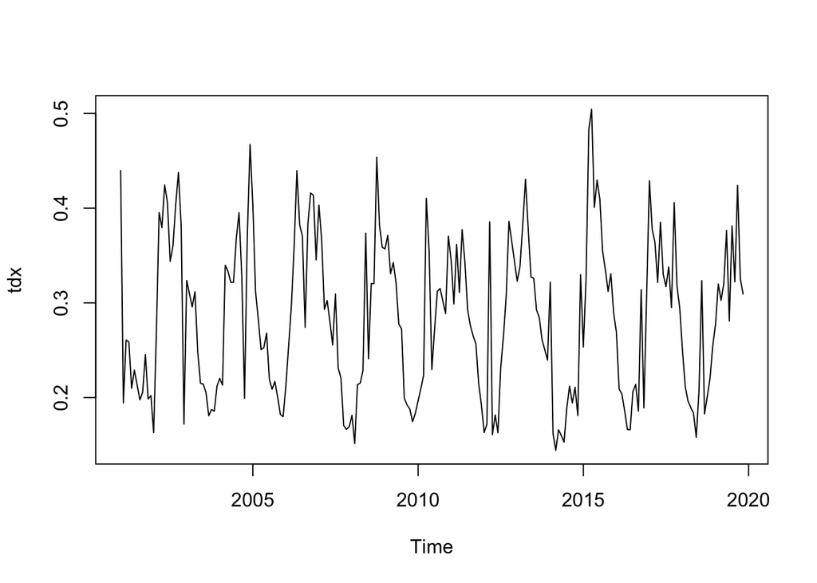

```r
tdx <- ts(data = subset$evi, start = c(2001, 1), end = c(2019, 11), frequency = 12) #convert data to time series.
plot(tdx)
```

## Métodos de suavizado

### Médias móviles

En el análisis de series temporales, el método de medias móviles tiene diversas aplicaciones: así, este método puede sernos útil si queremos calcular la tendencia de una serie temporal sin tener que ajustarnos a una función previa, ofreciendo así una visión suavizada o alisada de una serie, ya que promediando varios valores se elimina parte de los movimientos irregulares de la serie; también puede servirnos para realizar predicciones cuando la tendencia de la serie tiene una media constante.

Veamos qué es una media móvil: se trata, sencillamente de una media aritmética que se caracteriza porque toma un valor para cada momento del tiempo y porque en su cálculo no entran todas las observaciones de la muestra disponible.

Entre los distintos tipos de medias móviles que se pueden construir nos vamos a referir a dos tipos: medias móviles centradas y medias móviles asimétricas. El primer tipo se utiliza para la representación de la tendencia, mientras que el segundo lo aplicaremos para la predicción en modelos con media constante.

Las medias móviles centradas se caracterizan porque el número de observaciones que entran en su cálculo es impar, asignándose cada media móvil a la observación central. Así, una media móvil centrada en t de longitud 2n+1 viene dada por la siguiente expresión:

$$MM(2n+1)_t=(Y_{t−n}+Y_{t−n+1}+...+Y_t+...+Y_{t+n−1}+Y_{t+n2n+1})/(2n+1)$$

Como puede observarse, el subíndice asignado a la media móvil, t, es el mismo que el de la observación central, Yt. Obsérvese también que, por construcción, no se pueden calcular las medias móviles correspondientes a las n primeras y a las n últimas observaciones.

Por su parte, en el caso de las medias móviles asimétricas (no centradas) se asigna cada media móvil al período correspondiente a la observación más adelantada de todas las que intervienen en su cálculo. Así, la media móvil asimétrica de n puntos asociada a la observación t tendrá la siguiente expresión:

$$MMA(n)_t=(Y_{t−n+1}+Y_{t−n+2}+...+Y_{t−1}+Y_{t})/n$$

La utilización de medias móviles implica la elección arbitraria de su longitud u orden, es decir, del número de observaciones que intervienen en el cálculo de cada media móvil. Cuanto mayor sea la longitud, mejor se eliminarán las irregularidades de la serie, ya que al intervenir más observaciones en su cálculo se compensarán las fluctuaciones de este tipo, pero por el contrario, el coste informativo será mayor. Por el contrario, cuando la longitud es pequeña, la media móvil refleja con mayor rapidez los cambios que puedan producirse en la evolución de la serie. Es conveniente, pues, sopesar estos factores al decidir la longitud de la media móvil.

```r
library(vars)
```

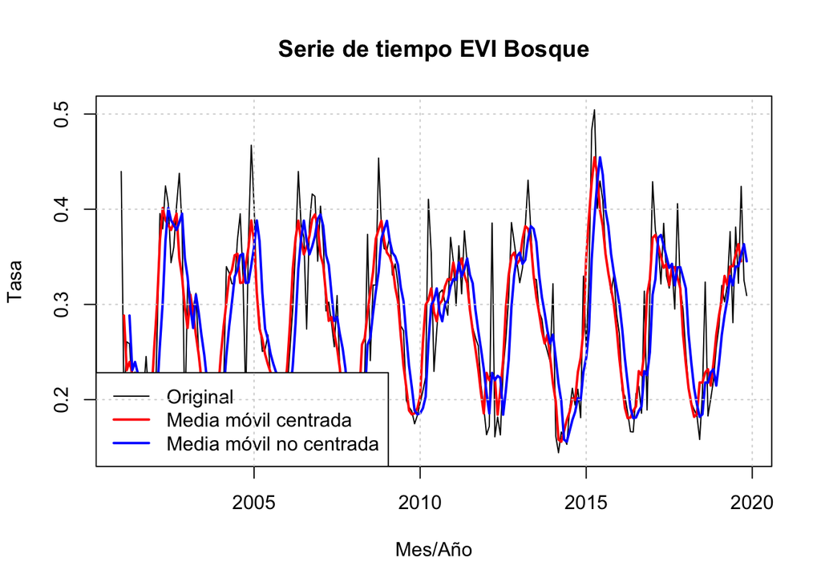

```r
plot(tdx, main='Serie de tiempo EVI Bosque', xlab='Mes/Año', ylab='Tasa')
lines(rollmean(tdx, 4), col="red", lwd=2)
lines(rollmean(tdx, 4,align="right"), col="blue", lwd=2)
legend("bottomleft", c("Original", "Media móvil centrada",
   "Media móvil no centrada"),
   lwd=c(1,2,2), col=c("black", "red", "blue"))
grid()
```

## Descomposición de una serie temporal

Tradicionalmente, en los métodos de descomposición de series temporales, se parte de la idea de que la serie temporal se puede descomponer en todos o algunos de los siguientes componentes:

- Tendencia (T), que representa la evolución de la serie en el largo plazo
- Fluctuación cíclica (C), que refleja las fluctuaciones de carácter periódico, pero no necesariamente regular, a medio plazo en torno a la tendencia. Este componente es frecuente hallarlo en las series económicas, y se debe a los cambios en la actividad económica.

Para la obtención de la tendencia es necesario disponer de una serie larga y de un número de ciclos completo, para que ésta no se vea influida por la fase del ciclo en que finaliza la serie, por lo que, a veces, resulta difícil separar ambos componentes. En estos casos resulta útil englobar ambos componentes en uno solo, denominado ciclo-tendencia o tendencia generalizada.

- Variación Estacional (S): recoge aquellos comportamientos de tipo regular y repetitivo que se dan a lo largo de un período de tiempo, generalmente igual o inferior a un año, y que son producidos por factores tales como las variaciones climatológicas, las vacaciones, las fiestas, etc.
- Movimientos Irregulares (I), que pueden ser aleatorios, la cual recoge los pequeños efectos accidentales, o erráticos, como resultado de hechos no previsibles, pero identificables a posteriori (huelgas, catástrofes, etc.)

En este punto, cabe señalar que en una serie concreta no tienen por qué darse los cuatro componentes. Así, por ejemplo, una serie con periodicidad anual carece de estacionalidad.

La asociación de estos cuatro componentes en una serie temporal, Y, puede responder a distintos esquemas; así, puede ser de tipo aditivo:

$$Y_t=T_t+C_t+S_t+e_t$$

También puede tener una forma multiplicativa:

$$Y_t=T_tC_tS_te_t$$

O bien ser una combinación de ambos, por ejemplo:

$$Y_t=T_tC_tS_t+e_t$$

En este capítulo se introducen algunas de las herramientas de R para la implementación de la descomposición
$$Y_t=T_t+S_t+e_t$$
, y para la estimación de la tendencia Tt. Hay que hacer énfasis en que estos métodos no asumen un modelo global para la tendencia, sino local, es decir, no son modelos con parámetros fijos, de la forma, por ejemplo,
$$Tt=/beta_0+/beta_1 t$$
, sino que
$$/beta_0$$
y
$$/beta_1$$
cambian en el tiempo para permitir mayor flexibilidad.

Las funciones decompose() y stl() realizan una descomposición de la serie Yt en las tres componentes.

La función calcula el componente de tendencia utilizando medias móviles, (si filter = NULL, se utilizan medias móviles simétricas), los índices de estacionalidad son promedios de los indices de estacionalidad que se obtienen al desestacionalizar la serie por el modelo elegido, por último, el componente irregular se obtiene eliminando la tendencia y estacionalidad de la serie temporal.

La función requiere que los datos tengan forma de serie temporal.

A continuación se realiza un sencillo ejercicio de utilización de la función “stl”:

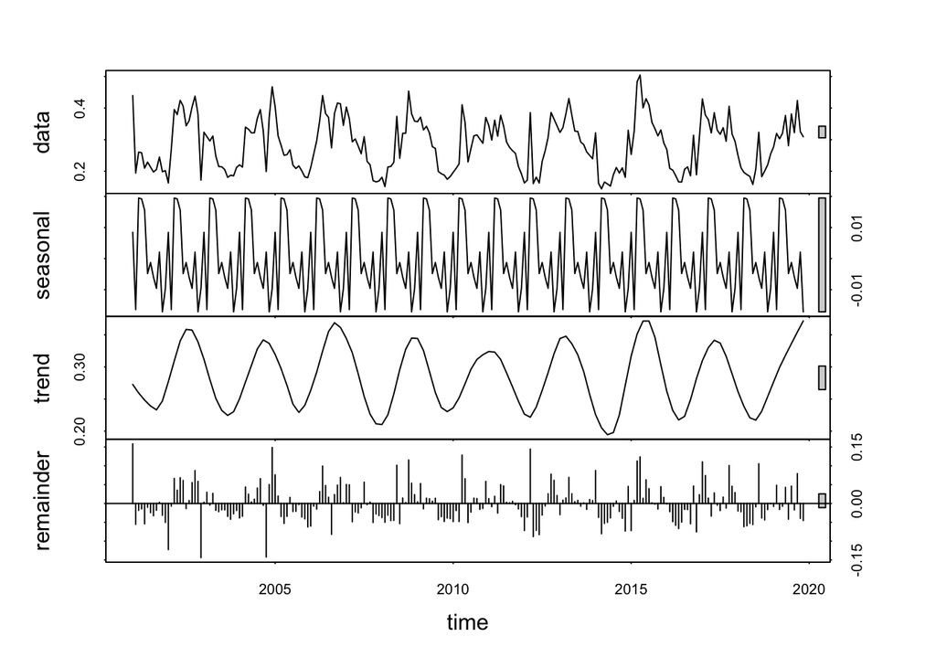

```r
tdx.dcp <- stl(tdx, s.window = 'periodic')
plot(tdx.dcp)
```

Este producto es un compuesto generado cada 16 días, a 250 m de resolución, a partir de las imágenes diarias tomadas por MODIS. Debido a la superposición de órbitas y la multiplicidad de observaciones en un mismo día, en algunas regiones pueden haber hasta 64 observaciones en un ciclo de 16 días. El algoritmo de MODIS, sin embargo, selecciona las observaciones de mayor calidad favoreciendo, principalmente, la ausencia de nubes y observaciones más cercanas a nadir.

Desde la Colección 6 , para la generación del producto MOD13Q1 se utilizan compuestos previos de 8 días. Si los valores de ambos compuestos para un píxel son de buena calidad, para el producto de 16 días se elige al de menor ángulo de observación es decir, el más cercano a nadir (Constrained View angle - Maximum Value Composite,CV-MVC). Si no hay observaciones de buena calidad, se elige la de mayor NDVI (Maximum Value Composite, CV-MVC). En el caso de que no haya observaciones disponibles, se rellena con un promedio histórico.

Por este motivo, vamos a volver a realizar la descomposición pero con el promedio movil.

Del gráfico se observa que :

- Existe un componente estacional relacionado con la caída de las hojas dado que es un bosque caducifolio.
- Presencia un componente de tendencia debido a variaciones interanuales (e.g el niño, la niña).
- El error es del orden de +/-0.05, lo cúal redujo considerablemente con respecto al análisis anterior.

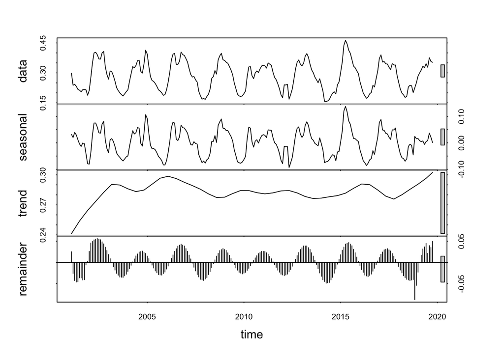

```r
tdx.dcp <- stl(rollmean(tdx, 3),s.window=2, t.window =48)
plot(tdx.dcp)
```

### Serie de tiempo de área deforestada

La deforestación se presenta como un punto de quiebre o cambio estructural en algunas o todas las series de las bandas que corresponden al píxel deforestado. En principio, se podría asumir que es suficiente con la clase Deforestación para abordar esta tarea (desarrollo y validación de metodologías), ya que las mismas series contienen la información necesaria para detectar un quiebre en ellas (ver, por ejemplo, NRT-CCDC).

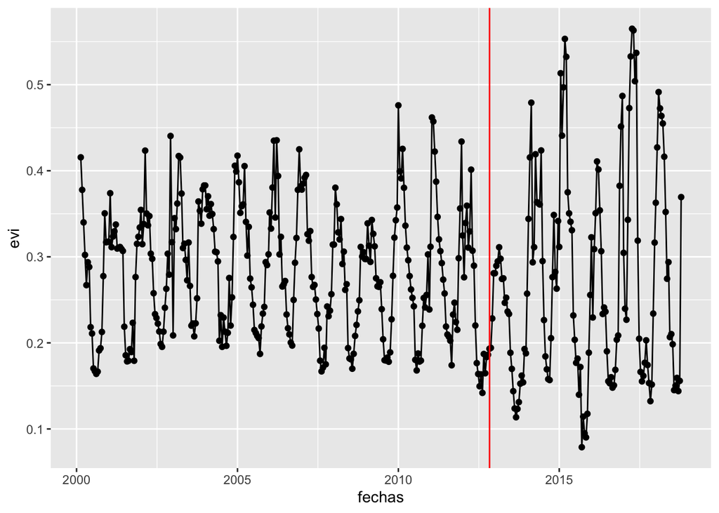

```r
data_nb <- read.csv("data/Sitio1_deforestacion_val.csv")
#head(iris)
subset_nb <- t(data_nb[1,8:437])
subset_nb <-subset_nb %>% as.data.frame(row.names = 1:nrow(.))

subset_nb<- merge(fechas,subset_nb, by= 'row.names', all = TRUE)
names(subset_nb)<- c('ind','fechas','evi')
breack<- as.POSIXct(c('2012-11-01'), format = "%Y-%m-%d" )
# basic scatterplot
  ggplot(subset_nb,aes(x=fechas, y=evi)) +
      geom_point() + geom_line(color="black")+
      geom_vline(xintercept=breack, color='red')
```

Ahora apliquemos el suavizado en esta nueva serie:

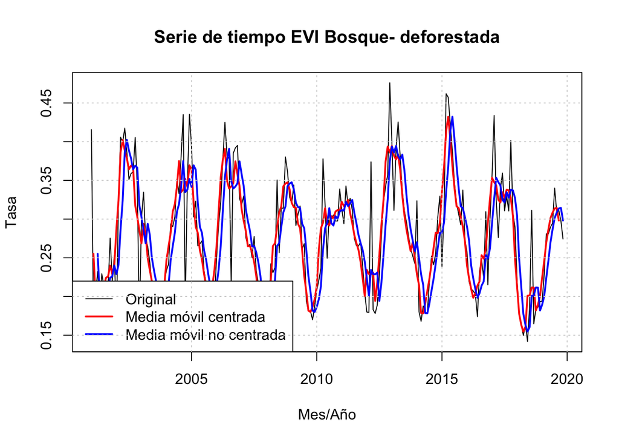

```r
tdx_nb<- ts(data = subset_nb$evi, start = c(2001, 1), end = c(2019, 11), frequency = 12) #convert data to time series.
plot(tdx_nb, main='Serie de tiempo EVI Bosque- deforestada', xlab='Mes/Año', ylab='Tasa')
lines(rollmean(tdx_nb, 4), col="red", lwd=2)
lines(rollmean(tdx_nb, 4,align="right"), col="blue", lwd=2)
legend("bottomleft", c("Original", "Media móvil centrada",
   "Media móvil no centrada"),
   lwd=c(1,2,2), col=c("black", "red", "blue"))
grid()
```

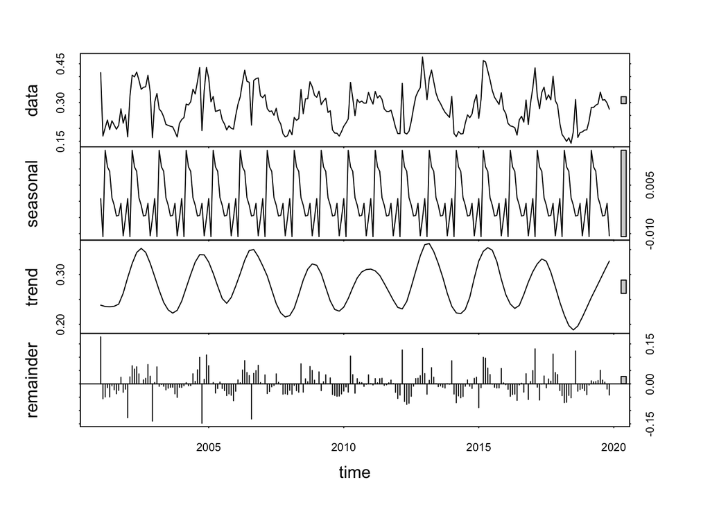

```r
tdx.dcp.np <- stl(tdx_nb, 2, s.window = 'periodic')
plot(tdx.dcp.np)
```